# Decision Tree, Naïve Bayes & Cross-validation

Jamison Orton

2026-06-16

# 1 Task 1: Data and Decision Tree

## 1.1 Question 1: Setup and starting code

### 1.1.1 Part A - Set up, data import and inspection code

```r
library(psych)
library(e1071)
library(matrixStats)
library(knitr)
library(C50)
library(caret)
library(rminer)
library(tictoc)
library(tidyverse)
mydir <- getwd()
setwd(mydir)

cd <- read.csv(file = "CD_additional_modified.csv", stringsAsFactors = TRUE)
```

```r
cd %>% str()
```

```
## 'data.frame':    4119 obs. of  21 variables:
##  $ age           : int  30 39 25 38 47 32 32 41 31 35 ...
##  $ job           : Factor w/ 12 levels "admin.","blue-collar",..: 2 8 8 8 1 8 1 3 8 2 ...
##  $ marital       : Factor w/ 4 levels "divorced","married",..: 2 3 2 2 2 3 3 2 1 2 ...
##  $ education     : Factor w/ 8 levels "basic.4y","basic.6y",..: 3 4 4 3 7 7 7 7 6 3 ...
##  $ default       : Factor w/ 3 levels "no","unknown",..: 1 1 1 1 1 1 1 2 1 2 ...
##  $ housing       : Factor w/ 3 levels "no","unknown",..: 3 1 3 2 3 1 3 3 1 1 ...
##  $ loan          : Factor w/ 3 levels "no","unknown",..: 1 1 1 2 1 1 1 1 1 1 ...
##  $ contact       : Factor w/ 2 levels "cellular","telephone": 1 2 2 2 1 1 1 1 1 2 ...
##  $ month         : Factor w/ 10 levels "apr","aug","dec",..: 7 7 5 5 8 10 10 8 8 7 ...
##  $ day_of_week   : Factor w/ 5 levels "fri","mon","thu",..: 1 1 5 1 2 3 2 2 4 3 ...
##  $ duration      : int  487 346 227 17 58 128 290 44 68 170 ...
##  $ campaign      : int  2 4 1 3 1 3 4 2 1 1 ...
##  $ pdays         : int  999 999 999 999 999 999 999 999 999 999 ...
##  $ previous      : int  0 0 0 0 0 2 0 0 1 0 ...
##  $ poutcome      : Factor w/ 3 levels "failure","nonexistent",..: 2 2 2 2 2 1 2 2 1 2 ...
##  $ emp.var.rate  : num  -1.8 1.1 1.4 1.4 -0.1 -1.1 -1.1 -0.1 -0.1 1.1 ...
##  $ cons.price.idx: num  92.9 94 94.5 94.5 93.2 ...
##  $ cons.conf.idx : num  -46.2 -36.4 -41.8 -41.8 -42 -37.5 -37.5 -42 -42 -36.4 ...
##  $ euribor3m     : num  1.31 4.86 4.96 4.96 4.19 ...
##  $ nr.employed   : num  5099 5191 5228 5228 5196 ...
##  $ y             : Factor w/ 2 levels "no","yes": 1 1 1 1 1 1 1 1 1 1 ...
```

```r
cd %>% summary()
```

```
##       age                 job           marital                   education
##  Min.   :18.00   admin.     :1012   divorced: 446   university.degree  :1264
##  1st Qu.:32.00   blue-collar: 884   married :2509   high.school        : 921
##  Median :38.00   technician : 691   single  :1153   basic.9y           : 574
##  Mean   :40.11   services   : 393   unknown :  11   professional.course: 535
##  3rd Qu.:47.00   management : 324                   basic.4y           : 429
##  Max.   :88.00   retired    : 166                   basic.6y           : 228
##                  (Other)    : 649                   (Other)            : 168
##     default        housing          loan           contact         month
##  no     :3315   no     :1839   no     :3349   cellular :2652   may    :1378
##  unknown: 803   unknown: 105   unknown: 105   telephone:1467   jul    : 711
##  yes    :   1   yes    :2175   yes    : 665                    aug    : 636
##                                                                jun    : 530
##                                                                nov    : 446
##                                                                apr    : 215
##                                                                (Other): 203
##  day_of_week    duration         campaign          pdays          previous
##  fri:768     Min.   :   0.0   Min.   : 1.000   Min.   :  0.0   Min.   :0.0000
##  mon:855     1st Qu.: 103.0   1st Qu.: 1.000   1st Qu.:999.0   1st Qu.:0.0000
##  thu:860     Median : 181.0   Median : 2.000   Median :999.0   Median :0.0000
##  tue:841     Mean   : 256.8   Mean   : 2.537   Mean   :960.4   Mean   :0.1903
##  wed:795     3rd Qu.: 317.0   3rd Qu.: 3.000   3rd Qu.:999.0   3rd Qu.:0.0000
##              Max.   :3643.0   Max.   :35.000   Max.   :999.0   Max.   :6.0000
##
##         poutcome     emp.var.rate      cons.price.idx  cons.conf.idx
##  failure    : 454   Min.   :-3.40000   Min.   :92.20   Min.   :-50.8
##  nonexistent:3523   1st Qu.:-1.80000   1st Qu.:93.08   1st Qu.:-42.7
##  success    : 142   Median : 1.10000   Median :93.75   Median :-41.8
##                     Mean   : 0.08497   Mean   :93.58   Mean   :-40.5
##                     3rd Qu.: 1.40000   3rd Qu.:93.99   3rd Qu.:-36.4
##                     Max.   : 1.40000   Max.   :94.77   Max.   :-26.9
##
##    euribor3m      nr.employed     y
##  Min.   :0.635   Min.   :4964   no :3668
##  1st Qu.:1.334   1st Qu.:5099   yes: 451
##  Median :4.857   Median :5191
##  Mean   :3.621   Mean   :5166
##  3rd Qu.:4.961   3rd Qu.:5228
##  Max.   :5.045   Max.   :5228
##
```

### 1.1.2 Part B - Data preparation

```r
set.seed(123)

train_index <- createDataPartition(cd$y, p = 0.70, list = FALSE)

train <- cd[train_index, ]
test <- cd[-train_index, ]

train %>% summary()
```

```
##       age                 job          marital                   education
##  Min.   :19.00   admin.     :713   divorced: 301   university.degree  :872
##  1st Qu.:32.00   blue-collar:609   married :1729   high.school        :656
##  Median :38.00   technician :490   single  : 848   basic.9y           :396
##  Mean   :40.05   services   :287   unknown :   6   professional.course:380
##  3rd Qu.:47.00   management :228                   basic.4y           :299
##  Max.   :88.00   retired    :110                   basic.6y           :159
##                  (Other)    :447                   (Other)            :122
##     default        housing          loan           contact         month
##  no     :2324   no     :1301   no     :2358   cellular :1867   may    :967
##  unknown: 560   unknown:  69   unknown:  69   telephone:1017   jul    :508
##  yes    :   0   yes    :1514   yes    : 457                    aug    :452
##                                                                jun    :359
##                                                                nov    :311
##                                                                apr    :147
##                                                                (Other):140
##  day_of_week    duration         campaign          pdays          previous
##  fri:517     Min.   :   0.0   Min.   : 1.000   Min.   :  0.0   Min.   :0.0000
##  mon:619     1st Qu.: 102.0   1st Qu.: 1.000   1st Qu.:999.0   1st Qu.:0.0000
##  thu:598     Median : 180.0   Median : 2.000   Median :999.0   Median :0.0000
##  tue:583     Mean   : 256.3   Mean   : 2.551   Mean   :960.8   Mean   :0.1862
##  wed:567     3rd Qu.: 321.2   3rd Qu.: 3.000   3rd Qu.:999.0   3rd Qu.:0.0000
##              Max.   :1980.0   Max.   :35.000   Max.   :999.0   Max.   :6.0000
##
##         poutcome     emp.var.rate      cons.price.idx  cons.conf.idx
##  failure    : 315   Min.   :-3.40000   Min.   :92.20   Min.   :-50.80
##  nonexistent:2470   1st Qu.:-1.80000   1st Qu.:93.08   1st Qu.:-42.70
##  success    :  99   Median : 1.10000   Median :93.75   Median :-41.80
##                     Mean   : 0.08925   Mean   :93.57   Mean   :-40.44
##                     3rd Qu.: 1.40000   3rd Qu.:93.99   3rd Qu.:-36.40
##                     Max.   : 1.40000   Max.   :94.77   Max.   :-26.90
##
##    euribor3m      nr.employed     y
##  Min.   :0.635   Min.   :4964   no :2568
##  1st Qu.:1.334   1st Qu.:5099   yes: 316
##  Median :4.857   Median :5191
##  Mean   :3.628   Mean   :5167
##  3rd Qu.:4.961   3rd Qu.:5228
##  Max.   :4.970   Max.   :5228
##
```

```r
test %>% summary()
```

```
##       age                 job          marital                  education
##  Min.   :18.00   admin.     :299   divorced:145   university.degree  :392
##  1st Qu.:32.00   blue-collar:275   married :780   high.school        :265
##  Median :38.00   technician :201   single  :305   basic.9y           :178
##  Mean   :40.27   services   :106   unknown :  5   professional.course:155
##  3rd Qu.:48.00   management : 96                  basic.4y           :130
##  Max.   :86.00   retired    : 56                  basic.6y           : 69
##                  (Other)    :202                  (Other)            : 46
##     default       housing         loan          contact        month
##  no     :991   no     :538   no     :991   cellular :785   may    :411
##  unknown:243   unknown: 36   unknown: 36   telephone:450   jul    :203
##  yes    :  1   yes    :661   yes    :208                   aug    :184
##                                                            jun    :171
##                                                            nov    :135
##                                                            apr    : 68
##                                                            (Other): 63
##  day_of_week    duration         campaign          pdays          previous
##  fri:251     Min.   :   5.0   Min.   : 1.000   Min.   :  1.0   Min.   :0.0
##  mon:236     1st Qu.: 110.5   1st Qu.: 1.000   1st Qu.:999.0   1st Qu.:0.0
##  thu:262     Median : 182.0   Median : 2.000   Median :999.0   Median :0.0
##  tue:258     Mean   : 257.8   Mean   : 2.506   Mean   :959.6   Mean   :0.2
##  wed:228     3rd Qu.: 305.0   3rd Qu.: 3.000   3rd Qu.:999.0   3rd Qu.:0.0
##              Max.   :3643.0   Max.   :27.000   Max.   :999.0   Max.   :6.0
##
##         poutcome     emp.var.rate      cons.price.idx  cons.conf.idx
##  failure    : 139   Min.   :-3.40000   Min.   :92.20   Min.   :-50.80
##  nonexistent:1053   1st Qu.:-1.80000   1st Qu.:93.08   1st Qu.:-42.70
##  success    :  43   Median : 1.10000   Median :93.88   Median :-41.80
##                     Mean   : 0.07498   Mean   :93.59   Mean   :-40.63
##                     3rd Qu.: 1.40000   3rd Qu.:93.99   3rd Qu.:-36.40
##                     Max.   : 1.40000   Max.   :94.77   Max.   :-26.90
##
##    euribor3m      nr.employed     y
##  Min.   :0.635   Min.   :4964   no :1100
##  1st Qu.:1.334   1st Qu.:5099   yes: 135
##  Median :4.857   Median :5191
##  Mean   :3.605   Mean   :5166
##  3rd Qu.:4.961   3rd Qu.:5228
##  Max.   :5.045   Max.   :5228
##
```

### 1.1.3 Part C - Target variable

```r
cd %>%
  count(y) %>%
  mutate(percentage = round(n / sum(n) * 100, 2))
```

```
##     y    n percentage
## 1  no 3668      89.05
## 2 yes  451      10.95
```

```r
train %>%
  count(y) %>%
  mutate(percentage = round(n / sum(n) * 100, 2))
```

```
##     y    n percentage
## 1  no 2568      89.04
## 2 yes  316      10.96
```

```r
test %>%
  count(y) %>%
  mutate(percentage = round(n / sum(n) * 100, 2))
```

```
##     y    n percentage
## 1  no 1100      89.07
## 2 yes  135      10.93
```

## 1.2 Question 2: Simple Decision Tree Training and Testing

### 1.2.1 Part A - Simple Decision Tree model

```r
# Train default C5.0 model
c50_default <- C5.0(
  y ~ .,
  data = train
)

# Show model information
c50_default
```

```
##
## Call:
## C5.0.formula(formula = y ~ ., data = train)
##
## Classification Tree
## Number of samples: 2884
## Number of predictors: 20
##
## Tree size: 56
##
## Non-standard options: attempt to group attributes
```

```r
# Show model summary
summary(c50_default)
```

```
##
## Call:
## C5.0.formula(formula = y ~ ., data = train)
##
##
## C5.0 [Release 2.07 GPL Edition]      Thu Jun 18 14:59:46 2026
## -------------------------------
##
## Class specified by attribute `outcome'
##
## Read 2884 cases (21 attributes) from undefined.data
##
## Decision tree:
##
## pdays <= 12:
## :...euribor3m <= 0.717: yes (31/1)
## :   euribor3m > 0.717:
## :   :...duration > 209: yes (39/9)
## :       duration <= 209:
## :       :...previous <= 3: no (31/6)
## :           previous > 3: yes (2)
## pdays > 12:
## :...duration <= 402:
##     :...nr.employed <= 5076.2:
##     :   :...duration <= 162: no (111/11)
##     :   :   duration > 162:
##     :   :   :...contact = telephone: no (19/2)
##     :   :       contact = cellular:
##     :   :       :...month in {apr,aug,nov}: no (36/13)
##     :   :           month in {dec,jun,may,oct}: yes (38/11)
##     :   :           month = jul:
##     :   :           :...previous <= 0: yes (5/1)
##     :   :           :   previous > 0: no (6)
##     :   :           month = mar:
##     :   :           :...marital = divorced: no (2)
##     :   :           :   marital in {married,single,unknown}: yes (3)
##     :   :           month = sep:
##     :   :           :...campaign <= 1: no (9/2)
##     :   :               campaign > 1: yes (4/1)
##     :   nr.employed > 5076.2:
```

[output cut: 94 more lines]

```
##   72.12% cons.conf.idx
##    7.80% previous
##    6.41% job
##    4.92% month
##    4.23% contact
##    2.50% education
##    1.46% day_of_week
##    1.07% marital
##    0.52% age
##    0.49% housing
##    0.45% campaign
##    0.21% default
##
##
## Time: 0.0 secs
```

```r
# Predictions
train_pred_c50_default <- predict(c50_default, train)
test_pred_c50_default <- predict(c50_default, test)

# Confusion matrices
confusionMatrix(train_pred_c50_default, train$y)
```

```
## Confusion Matrix and Statistics
##
##           Reference
## Prediction   no  yes
##        no  2513   92
##        yes   55  224
##
##                Accuracy : 0.949
##                  95% CI : (0.9404, 0.9568)
##     No Information Rate : 0.8904
##     P-Value [Acc > NIR] : < 2.2e-16
##
##                   Kappa : 0.7246
##
##  Mcnemar's Test P-Value : 0.002985
##
##             Sensitivity : 0.9786
##             Specificity : 0.7089
##          Pos Pred Value : 0.9647
##          Neg Pred Value : 0.8029
##              Prevalence : 0.8904
##          Detection Rate : 0.8714
##    Detection Prevalence : 0.9033
##       Balanced Accuracy : 0.8437
##
##        'Positive' Class : no
##
```

```r
confusionMatrix(test_pred_c50_default, test$y)
```

```
## Confusion Matrix and Statistics
##
##           Reference
## Prediction   no  yes
##        no  1047   67
##        yes   53   68
##
##                Accuracy : 0.9028
##                  95% CI : (0.8849, 0.9188)
##     No Information Rate : 0.8907
##     P-Value [Acc > NIR] : 0.09144
##
##                   Kappa : 0.4772
##
##  Mcnemar's Test P-Value : 0.23533
##
##             Sensitivity : 0.9518
##             Specificity : 0.5037
##          Pos Pred Value : 0.9399
##          Neg Pred Value : 0.5620
##              Prevalence : 0.8907
##          Detection Rate : 0.8478
##    Detection Prevalence : 0.9020
##       Balanced Accuracy : 0.7278
##
##        'Positive' Class : no
##
```

```r
# Classification evaluation metrics
mmetric(
  y = train$y,
  x = train_pred_c50_default,
  metric = c("ACC", "PRECISION", "RECALL")
)
```

```
##        ACC PRECISION1 PRECISION2
##   94.90291   96.46833   80.28674
```

```r
mmetric(
  y = test$y,
  x = test_pred_c50_default,
  metric = c("ACC", "PRECISION", "RECALL")
)
```

```
##        ACC PRECISION1 PRECISION2
##   90.28340   93.98564   56.19835
```

### 1.2.2 Part B - Smaller cf for the same model

```r
train_c50_model <- function(cf_value) {
  C5.0(
    y ~ .,
    data = train,
    control = C5.0Control(
      CF = cf_value,
      earlyStopping = FALSE,
      noGlobalPruning = FALSE
    )
  )
}

model_cf_001 <- train_c50_model(0.001)
```

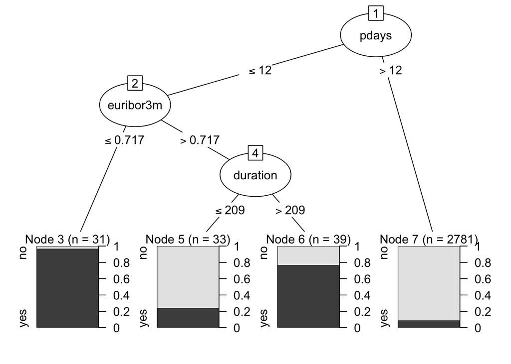

```r
plot(model_cf_001)
```

```r
# Generate predictions for training and testing sets
train_pred_cf_001 <- predict(model_cf_001, train)
test_pred_cf_001 <- predict(model_cf_001, test)

# Confusion matrices
confusionMatrix(train_pred_cf_001, train$y)
```

```
## Confusion Matrix and Statistics
##
##           Reference
## Prediction   no  yes
##        no  2558  256
##        yes   10   60
##
##                Accuracy : 0.9078
##                  95% CI : (0.8966, 0.9181)
##     No Information Rate : 0.8904
##     P-Value [Acc > NIR] : 0.001283
##
##                   Kappa : 0.2824
##
##  Mcnemar's Test P-Value : < 2.2e-16
##
##             Sensitivity : 0.9961
##             Specificity : 0.1899
##          Pos Pred Value : 0.9090
##          Neg Pred Value : 0.8571
##              Prevalence : 0.8904
##          Detection Rate : 0.8870
##    Detection Prevalence : 0.9757
##       Balanced Accuracy : 0.5930
##
##        'Positive' Class : no
##
```

```r
confusionMatrix(test_pred_cf_001, test$y)
```

```
## Confusion Matrix and Statistics
##
##           Reference
## Prediction   no  yes
##        no  1091  110
##        yes    9   25
##
##                Accuracy : 0.9036
##                  95% CI : (0.8858, 0.9195)
##     No Information Rate : 0.8907
##     P-Value [Acc > NIR] : 0.07689
##
##                   Kappa : 0.2635
##
##  Mcnemar's Test P-Value : < 2e-16
##
##             Sensitivity : 0.9918
##             Specificity : 0.1852
##          Pos Pred Value : 0.9084
##          Neg Pred Value : 0.7353
##              Prevalence : 0.8907
##          Detection Rate : 0.8834
##    Detection Prevalence : 0.9725
##       Balanced Accuracy : 0.5885
##
##        'Positive' Class : no
##
```

```r
# Classification evaluation metrics
mmetric(
  y = train$y,
  x = train_pred_cf_001,
  metric = c("ACC", "PRECISION", "RECALL")
)
```

```
##        ACC PRECISION1 PRECISION2
##   90.77670   90.90263   85.71429
```

```r
mmetric(
  y = test$y,
  x = test_pred_cf_001,
  metric = c("ACC", "PRECISION", "RECALL")
)
```

```
##        ACC PRECISION1 PRECISION2
##   90.36437   90.84097   73.52941
```

## 1.3 Question 3: Simple Naïve Bayes Model Training and Testing

### 1.3.1 Part A - Naive Bayes Model

```r
# Train naive Bayes model using the original training set
nb_default <- naiveBayes(
  y ~ .,
  data = train
)

# Show model information
nb_default
```

```
##
## Naive Bayes Classifier for Discrete Predictors
##
## Call:
## naiveBayes.default(x = X, y = Y, laplace = laplace)
##
## A-priori probabilities:
## Y
##      no     yes
## 0.89043 0.10957
##
## Conditional probabilities:
##      age
## Y         [,1]      [,2]
##   no  39.86916  9.801816
##   yes 41.49051 12.986070
##
##      job
## Y          admin. blue-collar entrepreneur   housemaid  management     retired
##   no  0.241822430 0.220015576  0.039719626 0.022585670 0.080218069 0.032710280
##   yes 0.291139241 0.139240506  0.018987342 0.022151899 0.069620253 0.082278481
##      job
## Y     self-employed    services     student  technician  unemployed     unknown
##   no    0.038161994 0.101635514 0.019470405 0.167834891 0.025311526 0.010514019
##   yes   0.018987342 0.082278481 0.041139241 0.186708861 0.041139241 0.006329114
##
##      marital
## Y        divorced     married      single     unknown
##   no  0.105919003 0.606308411 0.285436137 0.002336449
##   yes 0.091772152 0.544303797 0.363924051 0.000000000
##
##      education
## Y         basic.4y     basic.6y     basic.9y  high.school   illiterate
##   no  0.1055295950 0.0560747664 0.1421339564 0.2278037383 0.0003894081
##   yes 0.0886075949 0.0474683544 0.0981012658 0.2246835443 0.0000000000
##      education
## Y     professional.course university.degree      unknown
##   no         0.1304517134      0.2959501558 0.0416666667
##   yes        0.1424050633      0.3544303797 0.0443037975
##
```

[output cut: 68 more lines]

```
##
##      cons.conf.idx
## Y          [,1]     [,2]
##   no  -40.53657 4.410180
##   yes -39.69873 5.877274
##
##      euribor3m
## Y         [,1]     [,2]
##   no  3.813994 1.635652
##   yes 2.118899 1.755947
##
##      nr.employed
## Y         [,1]     [,2]
##   no  5175.933 65.65354
##   yes 5092.928 89.16038
```

```r
# Generate predictions for training and testing sets
train_pred_nb_default <- predict(nb_default, train)
test_pred_nb_default <- predict(nb_default, test)

# Confusion matrices
confusionMatrix(train_pred_nb_default, train$y, positive = "yes")
```

```
## Confusion Matrix and Statistics
##
##           Reference
## Prediction   no  yes
##        no  2302  119
##        yes  266  197
##
##                Accuracy : 0.8665
##                  95% CI : (0.8535, 0.8787)
##     No Information Rate : 0.8904
##     P-Value [Acc > NIR] : 1
##
##                   Kappa : 0.4318
##
##  Mcnemar's Test P-Value : 1e-13
##
##             Sensitivity : 0.62342
##             Specificity : 0.89642
##          Pos Pred Value : 0.42549
##          Neg Pred Value : 0.95085
##              Prevalence : 0.10957
##          Detection Rate : 0.06831
##    Detection Prevalence : 0.16054
##       Balanced Accuracy : 0.75992
##
##        'Positive' Class : yes
##
```

```r
confusionMatrix(test_pred_nb_default, test$y, positive = "yes")
```

```
## Confusion Matrix and Statistics
##
##           Reference
## Prediction  no yes
##        no  990  47
##        yes 110  88
##
##                Accuracy : 0.8729
##                  95% CI : (0.853, 0.891)
##     No Information Rate : 0.8907
##     P-Value [Acc > NIR] : 0.9781
##
##                   Kappa : 0.4581
##
##  Mcnemar's Test P-Value : 7.493e-07
##
##             Sensitivity : 0.65185
##             Specificity : 0.90000
##          Pos Pred Value : 0.44444
##          Neg Pred Value : 0.95468
##              Prevalence : 0.10931
##          Detection Rate : 0.07126
##    Detection Prevalence : 0.16032
##       Balanced Accuracy : 0.77593
##
##        'Positive' Class : yes
##
```

```r
# Classification evaluation metrics
mmetric(
  y = train$y,
  x = train_pred_nb_default,
  metric = c("ACC", "PRECISION", "RECALL")
)
```

```
##        ACC PRECISION1 PRECISION2
##   86.65049   95.08468   42.54860
```

```r
mmetric(
  y = test$y,
  x = test_pred_nb_default,
  metric = c("ACC", "PRECISION", "RECALL")
)
```

```
##        ACC PRECISION1 PRECISION2
##   87.28745   95.46770   44.44444
```

### 1.3.2 Part B - Removed Duration

```r
train_nb_reduced <- train %>%
  select(-duration)
test_nb_reduced <- test %>%
  select(-duration)

# Train naive Bayes model using the reduced training set
nb_reduced <- naiveBayes(
  y ~ .,
  data = train_nb_reduced
)

# Show model information
nb_reduced
```

```
##
## Naive Bayes Classifier for Discrete Predictors
##
## Call:
## naiveBayes.default(x = X, y = Y, laplace = laplace)
##
## A-priori probabilities:
## Y
##      no     yes
## 0.89043 0.10957
##
## Conditional probabilities:
##      age
## Y         [,1]      [,2]
##   no  39.86916  9.801816
##   yes 41.49051 12.986070
##
##      job
## Y          admin. blue-collar entrepreneur   housemaid  management     retired
##   no  0.241822430 0.220015576  0.039719626 0.022585670 0.080218069 0.032710280
##   yes 0.291139241 0.139240506  0.018987342 0.022151899 0.069620253 0.082278481
##      job
## Y     self-employed    services     student  technician  unemployed     unknown
##   no    0.038161994 0.101635514 0.019470405 0.167834891 0.025311526 0.010514019
##   yes   0.018987342 0.082278481 0.041139241 0.186708861 0.041139241 0.006329114
##
##      marital
## Y        divorced     married      single     unknown
##   no  0.105919003 0.606308411 0.285436137 0.002336449
##   yes 0.091772152 0.544303797 0.363924051 0.000000000
##
##      education
## Y         basic.4y     basic.6y     basic.9y  high.school   illiterate
##   no  0.1055295950 0.0560747664 0.1421339564 0.2278037383 0.0003894081
##   yes 0.0886075949 0.0474683544 0.0981012658 0.2246835443 0.0000000000
##      education
## Y     professional.course university.degree      unknown
##   no         0.1304517134      0.2959501558 0.0416666667
##   yes        0.1424050633      0.3544303797 0.0443037975
##
```

[output cut: 63 more lines]

```
##
##      cons.conf.idx
## Y          [,1]     [,2]
##   no  -40.53657 4.410180
##   yes -39.69873 5.877274
##
##      euribor3m
## Y         [,1]     [,2]
##   no  3.813994 1.635652
##   yes 2.118899 1.755947
##
##      nr.employed
## Y         [,1]     [,2]
##   no  5175.933 65.65354
##   yes 5092.928 89.16038
```

```r
# Generate predictions for training and testing sets
train_pred_nb_reduced <- predict(nb_reduced, train_nb_reduced)
test_pred_nb_reduced <- predict(nb_reduced, test_nb_reduced)

# Confusion matrices
confusionMatrix(train_pred_nb_reduced, train_nb_reduced$y, positive = "yes")
```

```
## Confusion Matrix and Statistics
##
##           Reference
## Prediction   no  yes
##        no  2256  145
##        yes  312  171
##
##                Accuracy : 0.8415
##                  95% CI : (0.8277, 0.8547)
##     No Information Rate : 0.8904
##     P-Value [Acc > NIR] : 1
##
##                   Kappa : 0.3407
##
##  Mcnemar's Test P-Value : 8.155e-15
##
##             Sensitivity : 0.54114
##             Specificity : 0.87850
##          Pos Pred Value : 0.35404
##          Neg Pred Value : 0.93961
##              Prevalence : 0.10957
##          Detection Rate : 0.05929
##    Detection Prevalence : 0.16748
##       Balanced Accuracy : 0.70982
##
##        'Positive' Class : yes
##
```

```r
confusionMatrix(test_pred_nb_reduced, test_nb_reduced$y, positive = "yes")
```

```
## Confusion Matrix and Statistics
##
##           Reference
## Prediction  no yes
##        no  963  66
##        yes 137  69
##
##                Accuracy : 0.8356
##                  95% CI : (0.8138, 0.8559)
##     No Information Rate : 0.8907
##     P-Value [Acc > NIR] : 1
##
##                   Kappa : 0.3141
##
##  Mcnemar's Test P-Value : 8.968e-07
##
##             Sensitivity : 0.51111
##             Specificity : 0.87545
##          Pos Pred Value : 0.33495
##          Neg Pred Value : 0.93586
##              Prevalence : 0.10931
##          Detection Rate : 0.05587
##    Detection Prevalence : 0.16680
##       Balanced Accuracy : 0.69328
##
##        'Positive' Class : yes
##
```

```r
# Classification evaluation metrics
mmetric(
  y = train_nb_reduced$y,
  x = train_pred_nb_reduced,
  metric = c("ACC", "PRECISION", "RECALL")
)
```

```
##        ACC PRECISION1 PRECISION2
##   84.15395   93.96085   35.40373
```

```r
mmetric(
  y = test_nb_reduced$y,
  x = test_pred_nb_reduced,
  metric = c("ACC", "PRECISION", "RECALL")
)
```

```
##        ACC PRECISION1 PRECISION2
##   83.56275   93.58601   33.49515
```

## 1.4 Question 4: Create a Named Cross-validation Function – cv_function

### 1.4.1 Part A - Define cv_function

```r
cv_function <- function(df, target, nFolds, seedVal, classification, metrics_list)
{
  set.seed(seedVal)

  folds <- createFolds(df[, target], nFolds)

  cv_results <- lapply(folds, function(x)
  {
    train <- df[-x, names(df) != target]
    test  <- df[x, names(df) != target]

    train_target <- df[-x, target]
    test_target  <- df[x, target]

    classification_model <- classification(train, train_target)

    pred <- predict(classification_model, test)

    return(mmetric(test_target, pred, metrics_list))
  })

  cv_results_m <- as.matrix(as.data.frame(cv_results))

  cv_mean <- as.matrix(rowMeans(cv_results_m))
  colnames(cv_mean) <- "Mean"

  cv_sd <- as.matrix(rowSds(cv_results_m))
  colnames(cv_sd) <- "Sd"

  cv_all <- cbind(cv_results_m, cv_mean, cv_sd)

  kable(cv_all, digits = 2)
}
```

## 1.5 Question 5: 5-fold and 10-fold C5.0 and naive Bayes evaluation performance with cv_function

### 1.5.1 Part A - 5-fold and 10-fold C5.0 and Naive Bayes Evaluation

```r
# C5.0 classification function
c50_classification <- function(train, train_target)
{
  C5.0(
    x = train,
    y = train_target
  )
}

# Naive Bayes classification function
nb_classification <- function(train, train_target)
{
  naiveBayes(
    x = train,
    y = train_target
  )
}
```

```r
cv_function(
  df = cd,
  target = "y",
  nFolds = 5,
  seedVal = 123,
  classification = c50_classification,
  metrics_list = c("ACC", "PRECISION", "TPR", "F1")
)
```

|  | Fold1 | Fold2 | Fold3 | Fold4 | Fold5 | Mean | Sd |
| --- | --- | --- | --- | --- | --- | --- | --- |
| ACC | 90.77 | 89.44 | 90.17 | 90.17 | 90.05 | 90.12 | 0.47 |
| PRECISION1 | 94.21 | 93.89 | 94.06 | 93.58 | 94.17 | 93.99 | 0.26 |
| PRECISION2 | 58.75 | 51.72 | 55.42 | 56.58 | 54.65 | 55.43 | 2.58 |
| TPR1 | 95.50 | 94.28 | 94.96 | 95.50 | 94.69 | 94.98 | 0.53 |
| TPR2 | 52.22 | 50.00 | 51.11 | 47.25 | 52.22 | 50.56 | 2.07 |
| F11 | 94.85 | 94.09 | 94.51 | 94.53 | 94.43 | 94.48 | 0.27 |
| F12 | 55.29 | 50.85 | 53.18 | 51.50 | 53.41 | 52.85 | 1.75 |

```r
cv_function(
  df = cd,
  target = "y",
  nFolds = 10,
  seedVal = 123,
  classification = c50_classification,
  metrics_list = c("ACC", "PRECISION", "TPR", "F1")
)
```

|  | Fold01 | Fold02 | Fold03 | Fold04 | Fold05 | Fold06 | Fold07 | Fold08 | Fold09 | Fold10 | Mean | Sd |
| --- | --- | --- | --- | --- | --- | --- | --- | --- | --- | --- | --- | --- |
| ACC | 93.20 | 88.83 | 90.29 | 90.51 | 91.97 | 91.02 | 90.53 | 90.07 | 89.56 | 90.29 | 90.63 | 1.22 |
| PRECISION1 | 94.96 | 93.03 | 94.79 | 94.55 | 94.40 | 94.12 | 94.09 | 93.12 | 92.19 | 93.60 | 93.88 | 0.89 |
| PRECISION2 | 74.29 | 48.72 | 55.32 | 56.82 | 66.67 | 60.53 | 57.50 | 57.14 | 53.57 | 56.76 | 58.73 | 7.14 |
| TPR1 | 97.55 | 94.55 | 94.28 | 94.81 | 96.72 | 95.91 | 95.37 | 95.91 | 96.46 | 95.64 | 95.72 | 1.02 |
| TPR2 | 57.78 | 42.22 | 57.78 | 55.56 | 53.33 | 51.11 | 51.11 | 43.48 | 33.33 | 46.67 | 49.24 | 7.83 |
| F11 | 96.24 | 93.78 | 94.54 | 94.68 | 95.55 | 95.01 | 94.72 | 94.50 | 94.27 | 94.61 | 94.79 | 0.68 |
| F12 | 65.00 | 45.24 | 56.52 | 56.18 | 59.26 | 55.42 | 54.12 | 49.38 | 41.10 | 51.22 | 53.34 | 6.91 |

```r
cv_function(
  df = cd,
  target = "y",
  nFolds = 5,
  seedVal = 123,
  classification = nb_classification,
  metrics_list = c("ACC", "PRECISION", "TPR", "F1")
)
```

|  | Fold1 | Fold2 | Fold3 | Fold4 | Fold5 | Mean | Sd |
| --- | --- | --- | --- | --- | --- | --- | --- |
| ACC | 86.76 | 87.38 | 87.99 | 87.01 | 86.77 | 87.18 | 0.52 |
| PRECISION1 | 95.09 | 95.52 | 95.16 | 94.97 | 94.58 | 95.06 | 0.34 |
| PRECISION2 | 42.75 | 44.70 | 46.28 | 43.75 | 42.28 | 43.95 | 1.60 |
| TPR1 | 89.77 | 90.05 | 91.14 | 90.18 | 90.33 | 90.29 | 0.52 |
| TPR2 | 62.22 | 65.56 | 62.22 | 61.54 | 57.78 | 61.86 | 2.77 |
| F11 | 92.35 | 92.71 | 93.11 | 92.51 | 92.40 | 92.62 | 0.31 |
| F12 | 50.68 | 53.15 | 53.08 | 51.14 | 48.83 | 51.38 | 1.81 |

```r
cv_function(
  df = cd,
  target = "y",
  nFolds = 10,
  seedVal = 123,
  classification = nb_classification,
  metrics_list = c("ACC", "PRECISION", "TPR", "F1")
)
```

|  | Fold01 | Fold02 | Fold03 | Fold04 | Fold05 | Fold06 | Fold07 | Fold08 | Fold09 | Fold10 | Mean | Sd |
| --- | --- | --- | --- | --- | --- | --- | --- | --- | --- | --- | --- | --- |
| ACC | 85.19 | 84.71 | 84.95 | 88.32 | 88.08 | 90.53 | 87.38 | 88.62 | 88.35 | 85.68 | 87.18 | 1.95 |
| PRECISION1 | 95.81 | 94.97 | 95.52 | 94.92 | 95.68 | 96.86 | 94.37 | 94.94 | 94.68 | 93.26 | 95.10 | 0.96 |
| PRECISION2 | 39.74 | 37.84 | 38.96 | 47.37 | 46.88 | 54.84 | 43.86 | 49.12 | 47.27 | 37.50 | 44.34 | 5.74 |
| TPR1 | 87.19 | 87.47 | 87.19 | 91.80 | 90.71 | 92.37 | 91.28 | 92.10 | 92.10 | 90.46 | 90.27 | 2.15 |
| TPR2 | 68.89 | 62.22 | 66.67 | 60.00 | 66.67 | 75.56 | 55.56 | 60.87 | 57.78 | 46.67 | 62.09 | 7.99 |
| F11 | 91.30 | 91.06 | 91.17 | 93.33 | 93.13 | 94.56 | 92.80 | 93.50 | 93.37 | 91.84 | 92.61 | 1.19 |
| F12 | 50.41 | 47.06 | 49.18 | 52.94 | 55.05 | 63.55 | 49.02 | 54.37 | 52.00 | 41.58 | 51.52 | 5.77 |

# 2 Task 2: Reflections

After building the C5.0 decision tree, reduced-complexity C5.0 tree, naïve Bayes model, reduced-predictor naïve Bayes model, and cross-validation models, I learned that the “best” model depends on which performance goal matters most. The default C5.0 model had strong overall accuracy. On the test set, it reached about 90.28% accuracy, and the cross-validation results were similar, with about 90.12% mean accuracy for 5-fold CV and 90.63% mean accuracy for 10-fold CV. This suggests that the C5.0 model was fairly stable and performed well overall. However, the target variable is imbalanced, with many more “no” cases than “yes” cases, so accuracy alone does not tell the whole story. The default C5.0 model was good at predicting the majority “no” class, but its recall/TPR for the “yes” class was only about 50%.

When I lowered the CF value for the C5.0 model, the tree became less complex and more conservative. The reduced CF model had similar test accuracy, about 90.36%, and higher precision for the “yes” class, about 73.53%. However, this came at a major cost: the model only found about 18.52% of the actual “yes” cases. I would explain to a supervisor that this reduced tree is useful if we only want to contact customers when the model is very confident, but it would miss many potential positive responses.

The naïve Bayes model had lower overall accuracy than C5.0, about 87.29% on the test set, but it performed better at identifying the “yes” class. Its “yes” recall/TPR was about 65.19% on the test set, and the cross-validation results were consistent, with “yes” TPR around 61.86% for 5-fold CV and 62.09% for 10-fold CV. This means naïve Bayes may be preferred when the goal is to identify more potential positive customers, even if that means accepting more false positives. For example, if a marketing team can afford to follow up with extra customers, naïve Bayes may be more useful than C5.0 because it catches more of the actual “yes” cases.

I removed duration from the naïve Bayes model because it is often a very strong predictor in marketing-call data, but it may not be known until after the call has already happened. I expected that removing it might make the model more realistic, but the results got worse. Test accuracy dropped from about 87.29% to 83.56%, “yes” precision dropped from about 44.44% to 33.50%, and “yes” TPR dropped from about 65.19% to 51.11%. This shows that duration was providing important predictive information. Even though removing it may make sense from a business-timing perspective, it weakened the model’s ability to predict positive responses.

The cross-validation results were similar to the train/test split results, which gives me more confidence in the model comparisons. The C5.0 model consistently had higher accuracy, while naïve Bayes consistently had better recall for the “yes” class. I think cross-validation is the better evaluation method because it tests the model across multiple folds instead of relying on one random 70/30 split. The train/test split is easier to understand, but cross-validation gives a more reliable estimate of average performance and model stability. Overall, I would tell a supervisor that C5.0 is better for overall accuracy, while naïve Bayes is better if the business priority is finding more positive responders.